# Deliberative Polling in Bergen, Norway

Preliminary time schedule, 2020-2021

10/8/2020

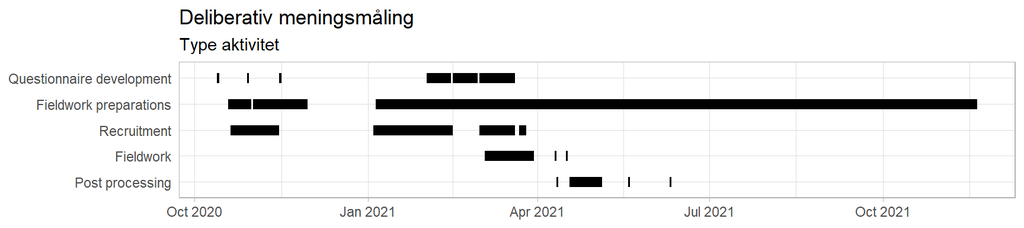

Det går litt på engelsk og norsk om hverandre her, siden Fishkin og co. også er involvert i denne planleggingen.

Figuren over viser hvordan vi jobber med de ulike delene av den deliberative meningsmålingen. *Stanford Online Deliberative Platform* er nettløsningen vi skal bruke. Her er jeg i dialog med kollegaene våre på Stanford om opplæring og tilpasning til norske forhold.

*Questionnaire development* viser til arbeidet med å komme fram til saker, lage spørsmål, og programmere undersøkelsen.

*Fieldwork preparations* er aktivitetene knyttet til den praktiske gjennomføringen av den deliberative meningsmålingen.

Oppgaver som knyttes til rekruttering av respondenter går under kategorien *Recruitment.*

*Fieldwork* viser til periodene hvor vi aktivt samler inn data.

*Post processing* er en samlekategori for alt som skjer i etterkant av den deliberative meningsmålingen.

Figuren og tabellen under viser en mer detaljer oversikt over oppgavene.

Det vi tenker at det er viktig at kommunen er involvert i er

1. Valg av saker. Her er vi godt i gang, og vi må være klar med det tidlig januar 2021.
2. Praktisk organisering av deliberativ meningsmåling. Utsendelse av invitasjon, og tilstedeværelse med nødvendig personell under gjennomføringen. Gjerne nå ut til nettverk av andre kommuner som kan være interessert i å være observatører.

Når det gjelder høsten 2021, så er mye usikkert pga koronasituasjonen. Vi kan likevel ta en runde om aktuelle datoer som kan passe å holde borgerpaneler.

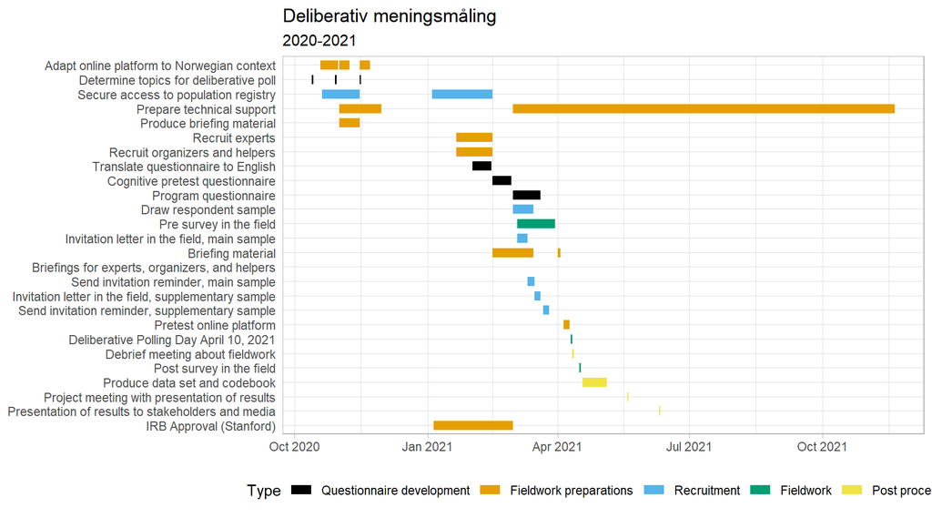

| Start_date | End_date | Action |
| --- | --- | --- |
| 2020.10.13 | 2020.10.14 | Determine topics for deliberative poll |
| 2020.10.19 | 2020.10.31 | Adapt online platform to Norwegian context |
| 2020.10.20 | 2020.11.15 | Secure access to population registry |
| 2020.10.20 | 2020.10.30 | Adapt online platform to Norwegian context |
| 2020.10.29 | 2020.10.30 | Determine topics for deliberative poll |
| 2020.11.01 | 2020.11.08 | Adapt online platform to Norwegian context |
| 2020.11.01 | 2020.11.08 | Produce briefing material |
| 2021.03.01 | 2021.11.20 | Prepare technical support |
| 2020.11.01 | 2020.11.30 | Prepare technical support |
| 2020.11.08 | 2020.11.15 | Produce briefing material |
| 2020.11.15 | 2020.11.16 | Determine topics for deliberative poll |
| 2020.11.15 | 2020.11.22 | Adapt online platform to Norwegian context |
| 2021.01.04 | 2021.02.15 | Secure access to population registry |
| 2021.01.21 | 2021.02.15 | Recruit experts |
| 2021.01.21 | 2021.02.15 | Recruit organizers and helpers |
| 2021.02.01 | 2021.02.14 | Translate questionnaire to English |
| 2021.02.15 | 2021.03.15 | Briefing material |
| 2021.02.15 | 2021.02.28 | Cognitive pretest questionnaire |
| 2021.03.01 | 2021.03.20 | Program questionnaire |
| 2021.03.01 | 2021.03.15 | Draw respondent sample |
| 2021.03.04 | 2021.03.30 | Pre survey in the field |
| 2021.03.04 | 2021.03.11 | Invitation letter in the field, main sample |
| 2021.03.11 | 2021.03.11 | Briefings for experts, organizers, and helpers |
| 2021.03.11 | 2021.03.16 | Send invitation reminder, main sample |
| 2021.03.16 | 2021.03.20 | Invitation letter in the field, supplementary sample |
| 2021.03.22 | 2021.03.26 | Send invitation reminder, supplementary sample |
| 2021.04.01 | 2021.04.03 | Briefing material |
| 2021.04.05 | 2021.04.06 | Pretest online platform |
| 2021.04.06 | 2021.04.07 | Pretest online platform |
| 2021.04.06 | 2021.04.09 | Pretest online platform |
| 2021.04.06 | 2021.04.09 | Pretest online platform |
| 2021.04.10 | 2021.04.11 | Deliberative Polling Day April 10, 2021 |
| 2021.04.10 | 2021.04.11 | Deliberative Polling Day April 10, 2021 |
| 2021.04.10 | 2021.04.11 | Deliberative Polling Day April 10, 2021 |
| 2021.04.11 | 2021.04.12 | Debrief meeting about fieldwork |
| 2021.04.16 | 2021.04.17 | Post survey in the field |
| 2021.04.18 | 2021.05.05 | Produce data set and codebook |
| 2021.05.19 | 2021.05.20 | Project meeting with presentation of results |
| 2021.06.10 | 2021.06.11 | Presentation of results to stakeholders and media |
| 2021.01.05 | 2021.03.01 | IRB Approval (Stanford) |